Данилова В., Пономарева М.

## Теория

#### Предмет исследования:

формы генитива и аккузатива неопределенного местоимения “что-то” в DO при переходных глаголах.

Для исследования было выбрано **пять** переходных глаголов(каждой форме несовершенного вида сопоставлена одна форма совершенного):  
- ждать/подождать  
- хотеть/захотеть  
- требовать/потребовать  
- искать/поискать  
- просить/попросить

#### Примеры интересующих нас случаев:

*Сергей все чего-то ждал.*  
*Она потребовала от него что-то невозможное.*  
*Каждый ищет что-то свое.*  
*Попросили что-то простое и незамысловатое.*

#### Выбор глаголов:

Чередование форм генитива и аккузатива встречается у целого ряда глаголов с семантикой физического восприятия и воздействия, перемещения, обладания, речевой деятельности, мыслительной и эмоциональной деятельности. Выбранные нами глаголы можно отнести к последней семантической группе. Мы намеренно ограничили выбор глаголами с близкой семантикой, предварительно оценив частотность интересующих нас случаев в корпусе.

#### Выбор объекта:

Известна зависимость выбора падежной формы от семантики DO (*“хочу яблок/яблоки”*, *“налить молока/молоко”*, на выбор влияет исчислимость объекта, значение партитивности, определенность и т.д.). Исследовать значимость этих факторов представляется нам интересной задачей, требующей больших усилий в первую очередь связанных с разметкой данных. В нашей работе мы сознательно ограничиваемся неопределенным местоимением в роли DO, повышая таким образом вероятность использования партитивного генитива при глаголе.

## Датасет

Мы проверяли влияние следующих факторов на выбор падежных форм: - вид глагола (совершенный vs несовершенный)  
- время глагола (прошедшее vs настоящее/будущее)  
- наличие прилагательного при местоимении  
- позиция местоимения относительно глагола (постпозиция vs препозиция)  
- глагольная пара

Четыре из перечисленных факторов являются бинарными, последний имеет 5 значений. Для всех возможных 80 комбинаций факторов мы искали примеры в НКРЯ, в датасет вошли все найденные релевантные примеры (1882 случая).

```r
library(readxl)
data_project <- read_excel("data_project_tf.xlsx")
data_project[1555:1585,]
```

```
##        Acc  past perfect adjective postposition    root
## 1555  TRUE  TRUE   FALSE     FALSE        FALSE   проси
## 1556  TRUE  TRUE   FALSE     FALSE        FALSE   проси
## 1557  TRUE  TRUE   FALSE     FALSE        FALSE   проси
## 1558  TRUE  TRUE   FALSE     FALSE        FALSE   проси
## 1559  TRUE  TRUE   FALSE     FALSE        FALSE   проси
## 1560  TRUE  TRUE   FALSE     FALSE        FALSE   проси
## 1561  TRUE  TRUE   FALSE     FALSE        FALSE   проси
## 1562  TRUE  TRUE   FALSE     FALSE        FALSE   проси
## 1563  TRUE  TRUE   FALSE     FALSE        FALSE   проси
## 1564  TRUE  TRUE   FALSE     FALSE        FALSE   проси
## 1565  TRUE  TRUE   FALSE     FALSE        FALSE   проси
## 1566  TRUE  TRUE   FALSE     FALSE        FALSE   проси
## 1567  TRUE  TRUE   FALSE     FALSE        FALSE   проси
## 1568  TRUE  TRUE   FALSE     FALSE        FALSE   проси
```

[output cut: 49 more lines]

## Гипотеза

Наша гипотеза: выбор падежного оформления DO зависит от глагола, факторы вида, времени, прилагательного и позиции местоимения могут в разной степени влиять на разные глагольные пары.

## Графики, отображающие распределение наших данных

```r
library(tidyverse)
data_project %>%
  select(root, Acc) %>%
  count(root, Acc) %>%
  spread(key = Acc, value = n) %>%
  mutate(sum = `TRUE`+`FALSE`,
        `T_%` = `TRUE`/sum*100,
        `F_%` = `FALSE`/sum*100) %>%
  select(-c(`TRUE`, `FALSE`, sum)) %>%
  gather(key = Acc, value = percent, `T_%`:`F_%`) %>%
  na.omit() -> data_rel
```

Общее соотношение употребления аккузатива и генитива для кажого из корней отображено на следующем графике:

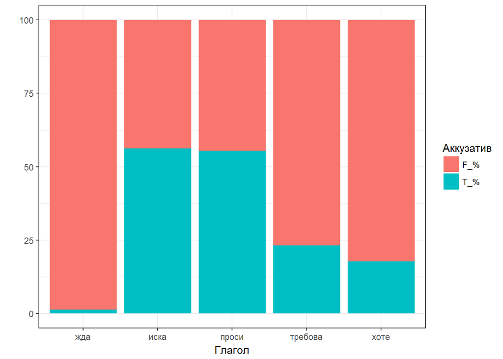

```r
data_rel %>%
  ggplot(aes(root, percent, fill = Acc)) +
  geom_bar(stat = "identity") +
  labs(x = "Глагол", y = "") +
  theme_bw() +
  guides(fill = guide_legend(title = "Аккузатив"))
```

Посмотрим на распределение примеров по каждому из факторов по отдельности.

Распределение падежа по фактору времени:

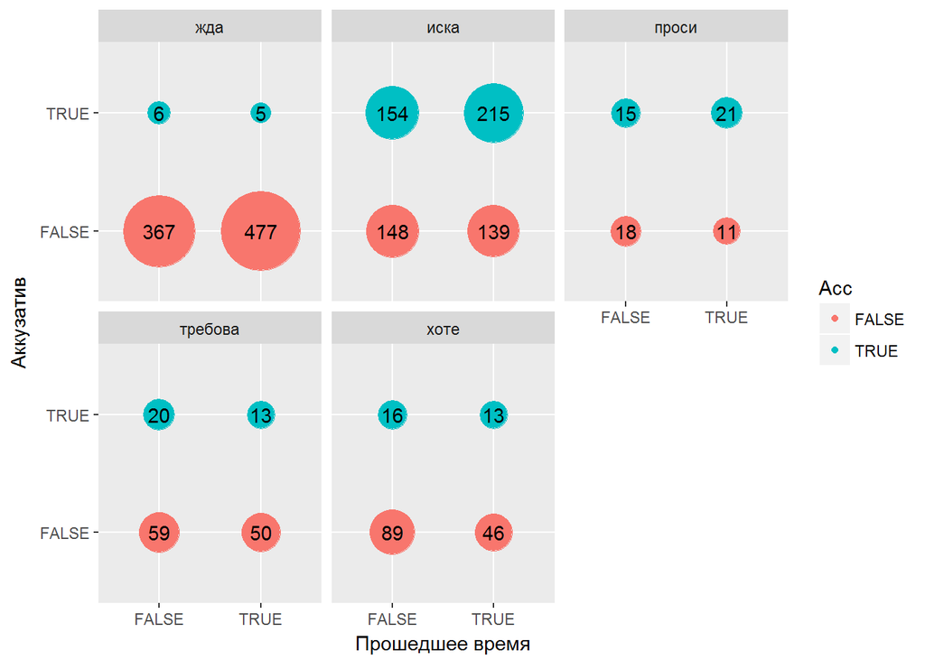

```r
data_project %>%
  group_by(past, Acc, root) %>%
  summarise(number = n()) %>%
  ggplot(aes(past, Acc, label = number))+
  geom_point(aes(size = number, color = Acc))+
  geom_text()+
  scale_size(range = c(5, 20))+
  facet_wrap(~root) +
  guides(size = F) +
  labs(x = "Прошедшее время", y = "Аккузатив")
```

Распределение падежа по фактору вида:

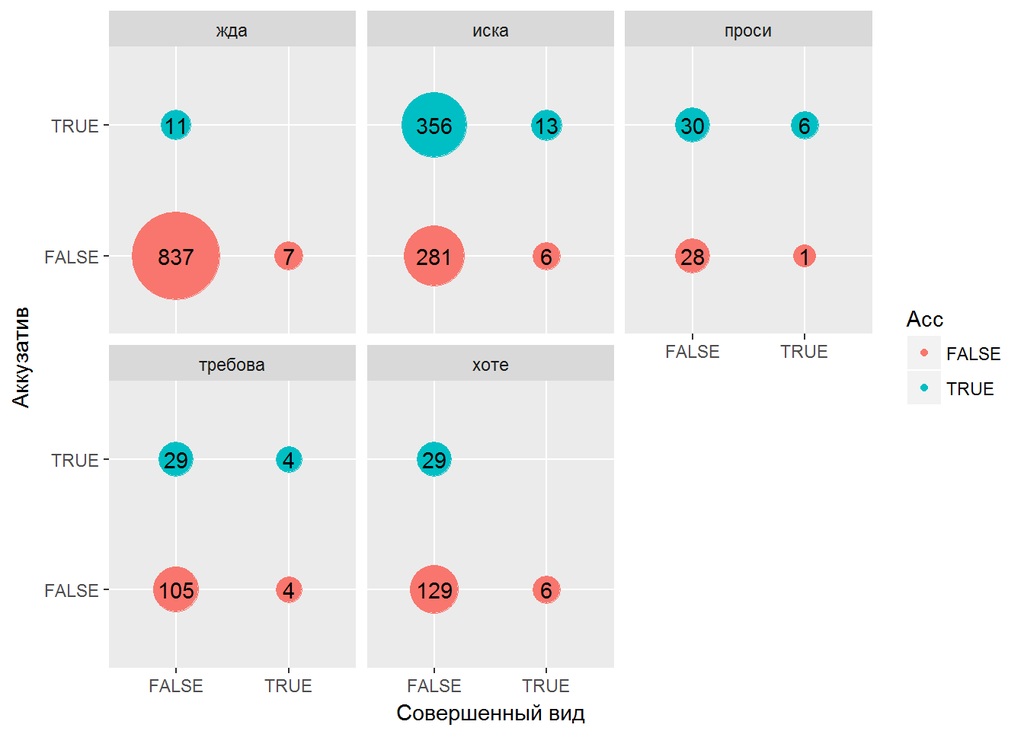

```r
data_project %>%
  group_by(perfect, Acc, root) %>%
  summarise(number = n()) %>%
  ggplot(aes(perfect, Acc, label = number))+
  geom_point(aes(size = number, color = Acc))+
  geom_text()+
  scale_size(range = c(5, 20))+
  facet_wrap(~root) +
  guides(size = F) +
  labs(x = "Совершенный вид", y = "Аккузатив")
```

Распределение падежа по фактору наличия зависимого прилагательного:

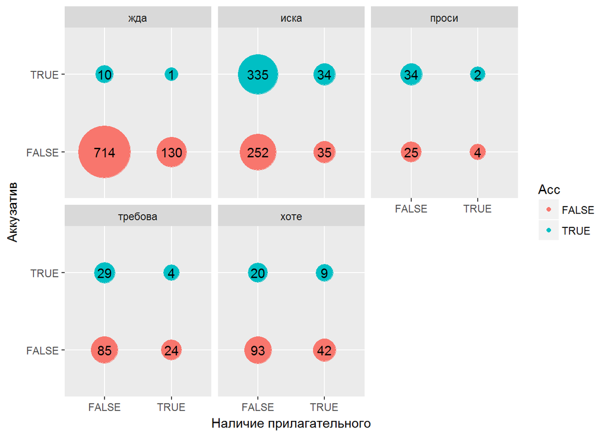

```r
data_project %>%
  group_by(adjective, Acc, root) %>%
  summarise(number = n()) %>%
  ggplot(aes(adjective, Acc, label = number))+
  geom_point(aes(size = number, color = Acc))+
  geom_text()+
  scale_size(range = c(5, 20))+
  facet_wrap(~root) +
  guides(size = F) +
  labs(x = "Наличие прилагательного", y = "Аккузатив")
```

Распределение падежа по фактору позиции местоимения по отношению к глаголу:

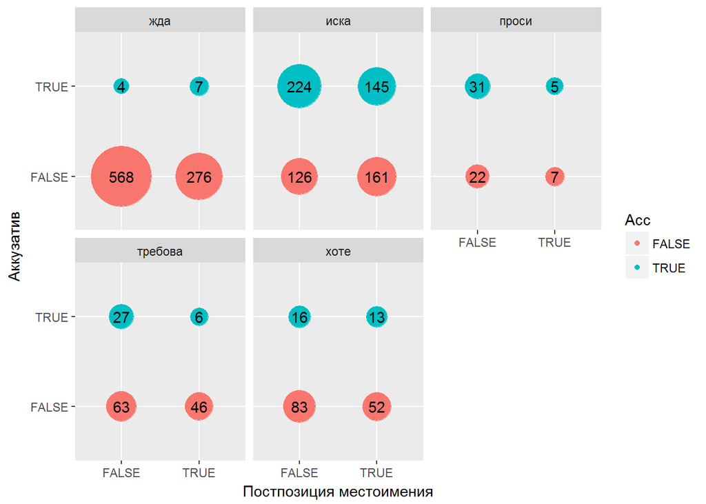

```r
data_project %>%
  group_by(postposition, Acc, root) %>%
  summarise(number = n()) %>%
  ggplot(aes(postposition, Acc, label = number))+
  geom_point(aes(size = number, color = Acc))+
  geom_text()+
  scale_size(range = c(5, 20))+
  facet_wrap(~root) +
  guides(size = F) +
  labs(x = "Постпозиция местоимения", y = "Аккузатив")
```

## Логистическая регрессия

Обучение модели логистической регрессии с использованием всех факторов:

```r
data <- read_excel("data_project.xlsx")
data <- data[,1:6]
fit <- glm(Acc ~ ., data = data, family = "binomial")
summary(fit)
```

```
##
## Call:
## glm(formula = Acc ~ ., family = "binomial", data = data)
##
## Deviance Residuals:
##     Min       1Q   Median       3Q      Max
## -1.7612  -0.6392  -0.1584   0.8736   3.1404
##
## Coefficients:
##               Estimate Std. Error z value Pr(>|z|)
## (Intercept)  -4.371859   0.316931 -13.794  < 2e-16 ***
## past          0.294861   0.132406   2.227 0.025951 *
## perfect       0.680710   0.351473   1.937 0.052778 .
## adjective     0.001277   0.216567   0.006 0.995293
## postposition -0.552085   0.149184  -3.701 0.000215 ***
## rootиска      4.708793   0.316536  14.876  < 2e-16 ***
## rootпроси     4.476417   0.396873  11.279  < 2e-16 ***
## rootтребова   3.180062   0.365358   8.704  < 2e-16 ***
## rootхоте      2.887441   0.369973   7.804 5.98e-15 ***
## ---
## Signif. codes:  0 '***' 0.001 '**' 0.01 '*' 0.05 '.' 0.1 ' ' 1
##
## (Dispersion parameter for binomial family taken to be 1)
##
##     Null deviance: 2132.9  on 1881  degrees of freedom
## Residual deviance: 1387.6  on 1873  degrees of freedom
## AIC: 1405.6
##
## Number of Fisher Scoring iterations: 7
```

Использование генитивных форм наиболее вероятно без учета других факторов. При этом коэффициенты для разных корней говорят о том, что фактор корня влияет сильнее всего на зависимую переменную. Глагол “ждать” с наибольшей вероятностью выбирает форму родительного падежа, сильно отличаясь от четырех других корней (что соответствует увиденному нами на графиках). Далее с повышением вероятности идут корни *хотеть*, *требовать*, *просить*, *искать*.

## Деревья решений

```r
library(party)
```

Дерево решений без учета влияния фактора глагольного корня:

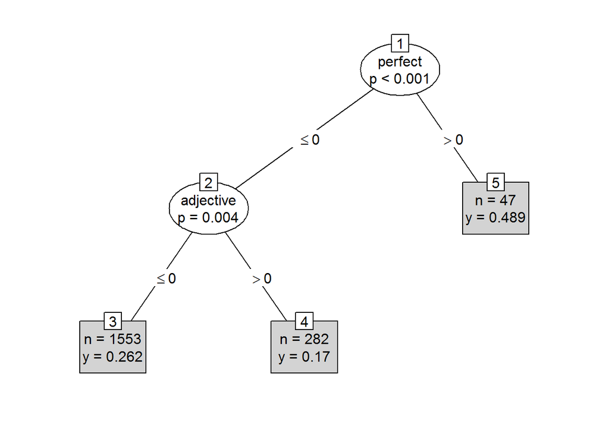

```r
my_tree <- ctree(Acc ~ past+perfect+adjective+postposition, data = data)
plot(my_tree, type = "simple")
```

Модель, обученная на данных всех корней, говорит нам о том, что для глаголов совершенного вида падежи почти равновероятны, в то время как для глаголов несовершенного вида более вероятен генитив, особенно при наличии зависимого прилагательного.

Построим деревья решений на наших данных, отдельно для каждого корня.

Дерево решений для глагола “искать”:

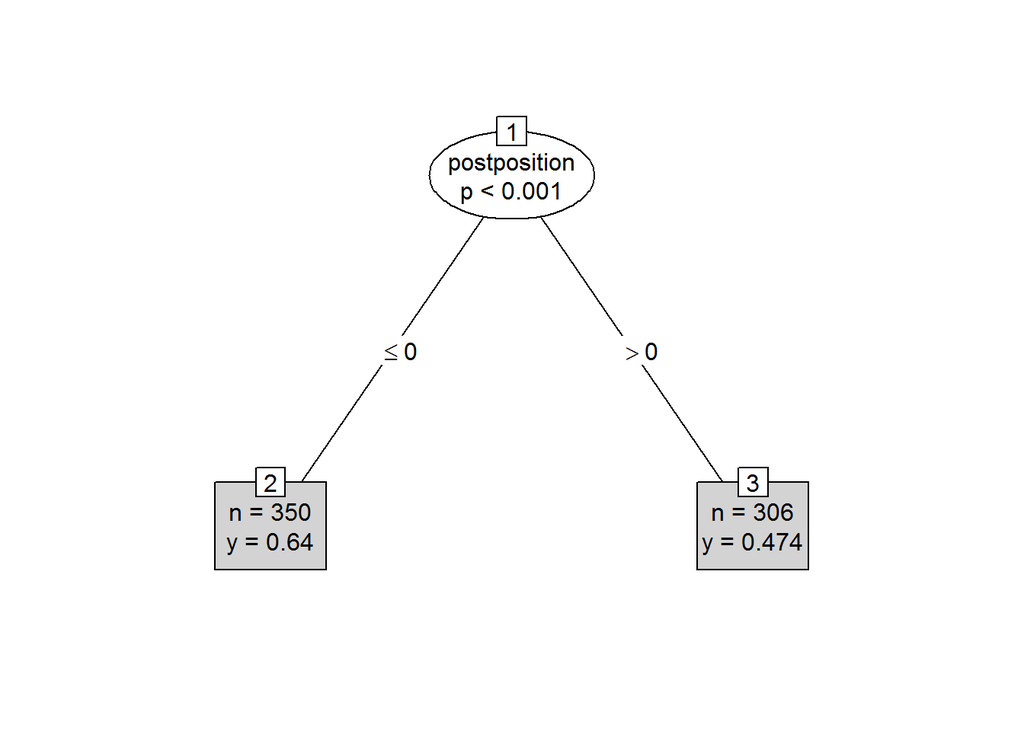

```r
data %>%
  filter(root=='иска') -> data_iska
my_tree <- ctree(Acc ~ past+perfect+adjective+postposition, data = data_iska)
plot(my_tree, type = "simple")
```

Дерево решений для глагола “требовать”:

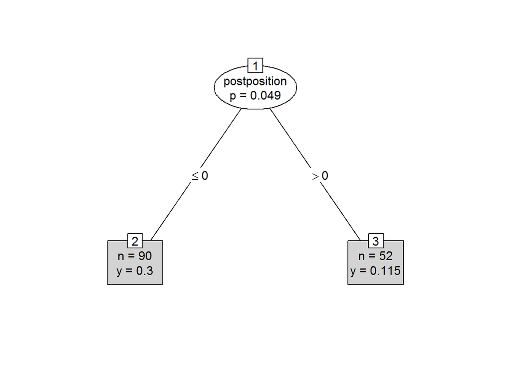

```r
data %>%
  filter(root=='требова') -> data_treb
my_tree <- ctree(Acc ~ past+perfect+adjective+postposition, data = data_treb)
plot(my_tree, type = "simple")
```

Модели предсказывают зависимость от позиции объекта для корней “искать” и “требовать”: при постпозиции вероятность аккузатива немного снижается. Для других корней все факторы являются недостаточно влиятельными

## Выводы

Лингвистический анализ: полученные результаты наглядно демонстрируют различие стратегий выбора падежной формы DO для разных глаголов и слабую зависимость выбора от таких факторов как вид, время, прилагательное и позиция. Интерпретируя результаты, скажем, что переходность представляется нам не строго бинарной характеристикой глагола, скорее можно говорить о градуальной шкале от Gen до Acc, и исследуемые нами глаголы выстраиваются на ней в следующем порядке ждать → хотеть → требовать → просить → искать.